# IB98D0 Advanced Data Analytics — Q1: A/B Testing of Loan Review Policies

2026-02-17

# Q1: A/B Testing of Loan Review Policies

This script evaluates two rule-based loan approval policies using historical LendingClub data. The analysis follows a simulated A/B test framework: borrowers are randomly assigned to Policy A or Policy B, and outcomes are compared on the primary OEC (average net return per application) and supporting secondary metrics.

## Step 1 — Load Libraries and Data

```r
library(dplyr)
```

```r
library(readr)
library(effsize)   # cohen.d() for effect size on the primary OEC
library(ggplot2)
library(tidyr)
library(patchwork)

df <- read_csv("early_2012_2013_loan_sample_with_outcome.csv",
               show_col_types = FALSE) %>%
  mutate(
    loan_is_bad = as.logical(loan_is_bad),
    is_good     = !loan_is_bad,
    grade       = as.character(grade),
    dti         = as.numeric(dti),
    delinq_2yrs = as.numeric(delinq_2yrs),
    funded_amnt             = as.numeric(funded_amnt),
    total_pymnt             = as.numeric(total_pymnt),
    recoveries              = as.numeric(recoveries),
    collection_recovery_fee = as.numeric(collection_recovery_fee),

    # Primary OEC — net return per application (cashflow proxy)
    # Formula: total payments received + recoveries - collection fees - amount funded
    # Rejected applications are assigned zero return (see Step 3)
    net_return = total_pymnt + recoveries - collection_recovery_fee - funded_amnt
  )
```

## Step 2 — Define Approval Rules

Two rule-based policies using origination-time variables only:

- **Policy A (lenient / growth-oriented):** DTI ≤ 30, grade A–F, delinq_2yrs ≤ 1
- **Policy B (strict / risk-controlled):** DTI ≤ 20, grade A–C, delinq_2yrs = 0

```r
# Policy A: lenient — maximise approval volume, exclude only extreme risk cases
approve_A <- with(df, dti <= 30 & grade %in% c("A","B","C","D","E","F") & delinq_2yrs <= 1)

# Policy B: strict — tighten all three thresholds for lower default exposure
approve_B <- with(df, dti <= 20 & grade %in% c("A","B","C") & delinq_2yrs == 0)
```

## Step 3 — Simulate A/B Assignment

Each borrower is randomly assigned to one policy. Rejected applications receive zero net return — capturing the full opportunity cost of over-restriction within the primary OEC rather than measuring only approved loans.

```r
set.seed(42)   # ensures reproducibility

df_exp <- df %>%
  mutate(
    assignment         = sample(c("A","B"), n(), replace = TRUE),
    approve            = ifelse(assignment == "A", approve_A, approve_B),
    net_return_per_app = ifelse(approve, net_return, 0)
  )
```

## Step 4 — Compute Summary Metrics

All metrics are computed per policy group. The primary OEC is `avg_net_return_per_app`. FNR, FPR, and bad rate are secondary metrics that decompose the components of the net return difference.

```r
metrics <- df_exp %>%
  group_by(assignment) %>%
  summarise(
    n             = n(),
    approvals     = sum(approve),
    approval_rate = mean(approve),

    # FNR — share of creditworthy borrowers incorrectly rejected
    # Secondary metric: captures opportunity cost of over-restriction
    FN         = sum(!approve & is_good),
    total_good = sum(is_good),
    FNR        = FN / total_good,

    # FPR — share of defaulters incorrectly approved
    # Secondary metric: captures portfolio risk
    FP        = sum(approve & !is_good),
    total_bad = sum(!is_good),
    FPR       = FP / total_bad,

    # Bad rate among approved loans — portfolio quality check
    bad_rate_approved = mean(!is_good[approve]),

    # Primary OEC — average net return per application (zeros for rejections)
    avg_net_return_per_app = mean(net_return_per_app, na.rm = TRUE),

    .groups = "drop"
  ) %>%
  arrange(assignment)

print(metrics)
```

```
## # A tibble: 2 × 12
##   assignment     n approvals approval_rate    FN total_good    FNR    FP
##   <chr>      <int>     <int>         <dbl> <int>      <int>  <dbl> <int>
## 1 A          25259     22622         0.896  2120      21253 0.0998  3489
## 2 B          24741     10562         0.427 11576      20933 0.553   1205
## # ℹ 4 more variables: total_bad <int>, FPR <dbl>, bad_rate_approved <dbl>,
## #   avg_net_return_per_app <dbl>
```

## Step 5 — Statistical Tests

Three secondary metrics support the primary OEC:

- **FNR** — opportunity cost of over-restriction (two-proportion z-test below)
- **FPR** — share of defaulters approved (two-proportion z-test below)
- **Bad rate among approved loans** — portfolio quality (descriptive; reported in Step 4 metrics table — no separate hypothesis test needed as it is a direct proportion of the approved group)

### 5a. Primary OEC: Net Return per Application (Welch t-test + Cohen’s d)

Net return per application is the primary OEC. The Welch t-test tests whether the difference in means is statistically significant. Cohen’s d measures the practical effect size — how large the difference is relative to the pooled standard deviation.

```r
# Welch t-test: does not assume equal variances — appropriate here given
# the different approval rates produce different variance structures
net_return_test <- t.test(net_return_per_app ~ assignment, data = df_exp)
print(net_return_test)
```

```
##
##  Welch Two Sample t-test
##
## data:  net_return_per_app by assignment
## t = 18.962, df = 38856, p-value < 2.2e-16
## alternative hypothesis: true difference in means between group A and group B is not equal to 0
## 95 percent confidence interval:
##  471.7663 580.5390
## sample estimates:
## mean in group A mean in group B
##        949.6455        423.4929
```

```r
# Cohen's d: practical effect size for the primary OEC difference
# Thresholds: negligible < 0.2, small < 0.5, medium < 0.8, large >= 0.8
# Note: d is expected to be small because including zero returns for all
# rejected applicants inflates variance in both groups, compressing d
# even when the absolute £ difference is economically substantial
cohen_d_result <- cohen.d(net_return_per_app ~ assignment, data = df_exp)
print(cohen_d_result)
```

```
##
## Cohen's d
##
## d estimate: 0.1686411 (negligible)
## 95 percent confidence interval:
##     lower     upper
## 0.1510781 0.1862040
```

```r
cat("Cohen's d =", round(abs(cohen_d_result$estimate), 3),
    " (", as.character(cohen_d_result$magnitude), "effect)\n")
```

```
## Cohen's d = 0.169  ( negligible effect)
```

### 5b. Secondary: FNR (two-proportion z-test)

FNR compares the share of creditworthy borrowers rejected under each policy. A two-proportion test is used as FNR is a proportion, not a continuous mean.

```r
fnr_test <- prop.test(x = metrics$FN, n = metrics$total_good, correct = FALSE)
print(fnr_test)
```

```
##
##  2-sample test for equality of proportions without continuity correction
##
## data:  metrics$FN out of metrics$total_good
## X-squared = 9881.3, df = 1, p-value < 2.2e-16
## alternative hypothesis: two.sided
## 95 percent confidence interval:
##  -0.4611000 -0.4454036
## sample estimates:
##     prop 1     prop 2
## 0.09975062 0.55300244
```

### 5c. Secondary: FPR (two-proportion z-test)

FPR compares the share of defaulters approved under each policy.

```r
fpr_test <- prop.test(x = metrics$FP, n = metrics$total_bad, correct = FALSE)
print(fpr_test)
```

```
##
##  2-sample test for equality of proportions without continuity correction
##
## data:  metrics$FP out of metrics$total_bad
## X-squared = 2502.6, df = 1, p-value < 2.2e-16
## alternative hypothesis: two.sided
## 95 percent confidence interval:
##  0.5364493 0.5725597
## sample estimates:
##    prop 1    prop 2
## 0.8709436 0.3164391
```

## Step 6 — Plots

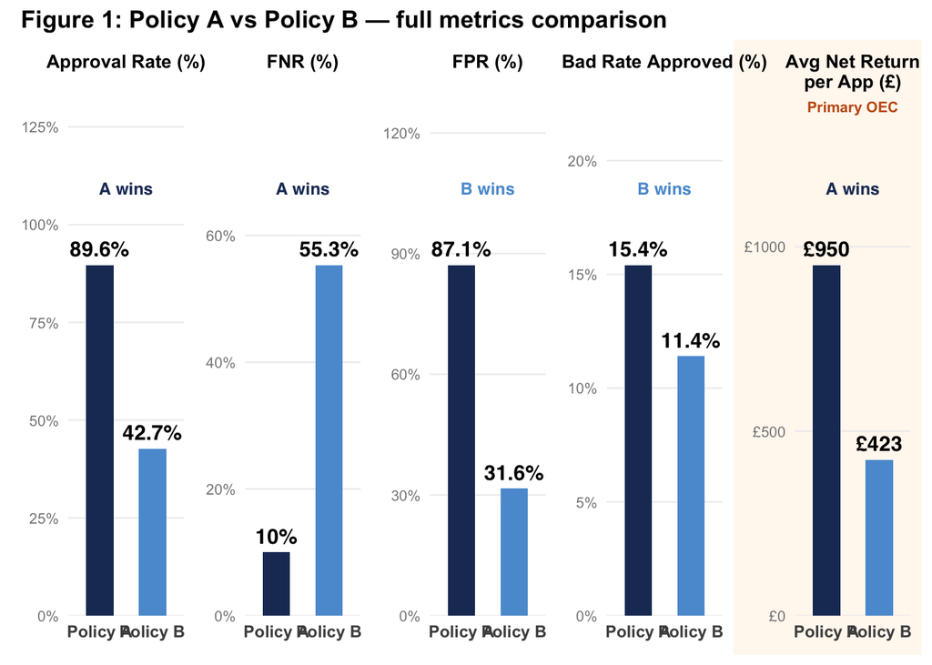

```r
# =============================================================================
# Figure 1: Policy A vs Policy B — Full Metrics Comparison
# =============================================================================


NAVY <- "#1F3864"
MID  <- "#5B9BD5"
GOLD <- "#C55A11"

# ── Build data from metrics object (computed in Step 4) ───────────────────────
plot_data <- metrics %>%
  select(assignment, approval_rate, FNR, FPR, bad_rate_approved,
         avg_net_return_per_app) %>%
  mutate(
    Policy              = ifelse(assignment == "A", "Policy A", "Policy B"),
    `Approval\nRate`    = round(approval_rate * 100, 1),
    `FNR`               = round(FNR * 100, 1),
    `FPR`               = round(FPR * 100, 1),
    `Bad Rate\nApproved`= round(bad_rate_approved * 100, 1),
    `Avg Net Return\nper App (£)` = round(avg_net_return_per_app, 0)
  )

policy_colours <- c("Policy A" = NAVY, "Policy B" = MID)

# ── Helper: build one panel ───────────────────────────────────────────────────
make_panel <- function(data, col, y_label, winner_label, winner_col,
                       is_primary = FALSE, value_fmt = "pct") {
  d <- data %>%
    select(Policy, Value = all_of(col)) %>%
    mutate(Policy = factor(Policy, levels = c("Policy A", "Policy B")))

  lbl <- if (value_fmt == "gbp") {
    paste0("£", round(d$Value, 0))
  } else {
    paste0(d$Value, "%")
  }
  d$label <- lbl

  p <- ggplot(d, aes(x = Policy, y = Value, fill = Policy)) +
    geom_col(width = 0.52, show.legend = FALSE) +
    geom_text(aes(label = label), vjust = -0.6,
              fontface = "bold", size = 4, family = "sans") +
    annotate("text", x = 1.5, y = max(d$Value) * 1.22,
             label = winner_label, colour = winner_col,
             fontface = "bold", size = 3.2, family = "sans") +
    scale_fill_manual(values = policy_colours) +
    scale_y_continuous(
      limits = c(0, max(d$Value) * 1.35),
      labels = if (value_fmt == "gbp") {
        function(x) paste0("£", round(x, 0))
      } else {
        function(x) paste0(x, "%")
      },
      expand = expansion(mult = c(0, 0.05))
    ) +
    labs(title = y_label, x = NULL, y = NULL) +
    theme_minimal(base_size = 11) +
    theme(
      plot.title         = element_text(face = "bold", size = 10,
                                        hjust = 0.5, colour = "black"),
      panel.grid.major.x = element_blank(),
      panel.grid.minor   = element_blank(),
      panel.grid.major.y = element_line(colour = "#EEEEEE", linewidth = 0.4),
      axis.text.x        = element_text(face = "bold", size = 9),
      axis.text.y        = element_text(colour = "#888888", size = 8),
      plot.background    = element_rect(
        fill = if (is_primary) "#FFF8F0" else "white", colour = NA),
      panel.background   = element_rect(
        fill = if (is_primary) "#FFF8F0" else "white", colour = NA),
      plot.margin        = margin(8, 6, 8, 6)
    )

  if (is_primary) {
    p <- p + labs(
      subtitle = "Primary OEC"
    ) + theme(
      plot.subtitle = element_text(colour = GOLD, size = 8,
                                   hjust = 0.5, face = "bold",
                                   margin = margin(b = 2))
    )
  }
  p
}

# ── Build all five panels ─────────────────────────────────────────────────────
p1 <- make_panel(plot_data, "Approval\nRate",    "Approval Rate (%)",
                 "A wins", NAVY)
p2 <- make_panel(plot_data, "FNR",               "FNR (%)",
                 "A wins", NAVY)
p3 <- make_panel(plot_data, "FPR",               "FPR (%)",
                 "B wins", MID)
p4 <- make_panel(plot_data, "Bad Rate\nApproved","Bad Rate Approved (%)",
                 "B wins", MID)
p5 <- make_panel(plot_data, "Avg Net Return\nper App (£)",
                 "Avg Net Return\nper App (£)",
                 "A wins", NAVY, is_primary = TRUE, value_fmt = "gbp")

# ── Combine ───────────────────────────────────────────────────────────────────
fig1 <- p1 + p2 + p3 + p4 + p5 +
  plot_layout(nrow = 1) +
  plot_annotation(
    title   = "Figure 1: Policy A vs Policy B — full metrics comparison",
    theme   = theme(
      plot.title    = element_text(face = "bold", size = 13, colour = "black",
                                   hjust = 0, margin = margin(b = 4)),
      plot.subtitle = element_text(colour = "#666666", size = 9, hjust = 0,
                                   margin = margin(b = 10)),
      plot.caption  = element_text(colour = "#AAAAAA", size = 8.5, hjust = 1),
      plot.background = element_rect(fill = "white", colour = NA)
    )
  )

ggsave("fig1_policy_comparison.png", fig1,
       width = 14, height = 5, dpi = 180, bg = "white")
print(fig1)
```

## Step 7 — Decision

Policy A is preferred on the primary OEC: it generates a significantly higher average net return per application (see net_return_test above). The secondary metrics confirm Policy B produces a safer portfolio (lower FPR, lower bad rate) but at the cost of substantially higher FNR and lower aggregate return — insufficient to offset the revenue penalty.